# SPS 506 · Class 8

## Outcome and Impact Evaluation

SPS 506 · Public Program Evaluation · October 22, 2026

Outcome and  
Impact Evaluation

Compared to what? Comparison groups and random assignment

## IHLA students scored well below the state average in 2024–25

Idaho Home Learning Academy · from the Office of Performance Evaluations (OPE) report, 2025

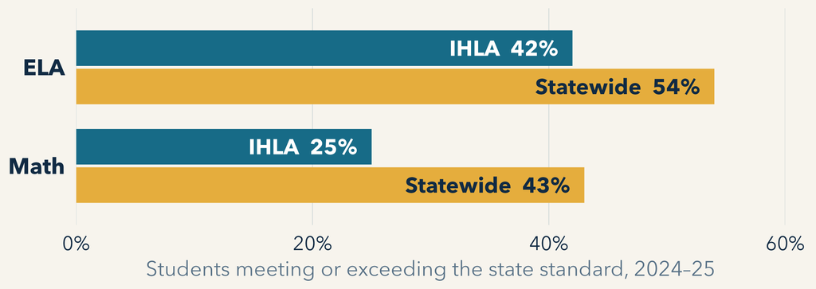

Does this gap tell you what IHLA does to a student’s test scores?

OPE, *Idaho Home Learning Academy* (2025), pp. 40–41. IHLA ranked 141st of 177 districts and charters in ELA and 147th of 176 in math (p. 40)

## OPE compared IHLA’s scores three ways, and each comparison told a different story

1**Against the state average****IHLA lags well behind**42% proficient in ELA vs. 54% statewide, and 25% in math vs. 43%*pp. 40–41*

2**Against the same students’ own past****Growth fell the year students switched to IHLA**In their first year at IHLA, 35% grew in ELA and 22% in math. The year after leaving, 65% and 61%*p. 43*

3**Against four similar virtual schools****IHLA looks about the same**Two virtual charters and two district-run virtual schools. IHLA’s leaders agreed they were reasonable comparisons*p. 47*

All three use the same school and the same tests. **The answer depends on what you compare IHLA to.**

OPE, *Idaho Home Learning Academy* (2025). Growth is the share of students who raised their proficiency level from the prior year’s test (or stayed proficient)

## An impact is the difference between what happened and what would have happened without the program

**What happened****Outcomes for people in the program**You can measure this

−

**What would have happened****The same people’s outcomes without the program**You can never observe this

=

**Impact****The program’s effect**What the evaluation estimates

IHLA’s 42% is an **outcome**. Its **impact** is 42% minus what the same students would have scored without IHLA, and that missing number is the **counterfactual**.

Henry, Handbook ch. 6, pp. 137, 140. Never observing both outcomes is Holland’s “fundamental problem of causal inference”

## Each of OPE’s comparisons is a different guess about how IHLA students would have done without IHLA

Compared to

Without IHLA, it assumes students would…

What could make that guess wrong

The state average

score like the average Idaho student

Families who choose IHLA differ from other families before they enroll

Their own past

keep growing at the rate they had before

The switch itself, a bad year before moving, or other changes at the same time

Similar virtual schools

score like students at other large virtual schools

The schools are alike on what OPE could see, but maybe not on what it couldn’t

OPE, *Idaho Home Learning Academy* (2025), pp. 39–47

## Comparison groups

Part 1 · Henry, ch. 6

Comparison groups

When chance doesn’t decide who gets the program, the two groups start out different, and each design tries to correct for that

## A simple comparison works only if the two groups would have ended up the same without the program

“Do we expect that if the program had not been offered, the outcomes of the treated and untreated comparison groups would have been roughly the same?”

What IHLA parents told OPE

“Students who do not succeed in a traditional school setting seek out more individualized opportunities for learning.”

Parent, OPE p. 39

Selection bias

The people in a program differ from the people outside it in ways that also affect the outcome. It comes from **people choosing** the program, and from **staff choosing** who they think needs it or will benefit.

Henry calls it “the most pernicious form of bias” (p. 144)

Henry, Handbook ch. 6, pp. 141, 144. OPE, *Idaho Home Learning Academy* (2025), p. 39

## Following the same students rules out test unfamiliarity, but not the move itself or who leaves

Two mostly different groups: students entering IHLA from other public schools, and students leaving it

**Share of students who moved up an ISAT level or stayed proficient**

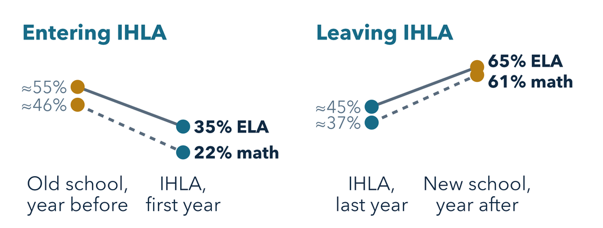

**Rules out**Unfamiliarity with testing. These students had taken the ISAT at their old school (p. 43)

Can’t rule out

**The move itself**Any new school takes adjusting. Growth at IHLA rose again in students’ second year (p. 45)

**Who leaves**Students who leave IHLA “may be more likely to succeed in a non-IHLA setting” (p. 44)

**Regression to the mean**Unusually low scores tend to move back toward average on their own (Henry, p. 146)

OPE, *Idaho Home Learning Academy* (2025), pp. 40 (growth defined), 43–45. Redrawn from Exhibit 19. OPE labels only the right-hand points; ≈ values are measured off its to-scale chart. Henry, Handbook ch. 6, p. 146

## Difference-in-differences uses a comparison group’s trend to show what would have happened anyway

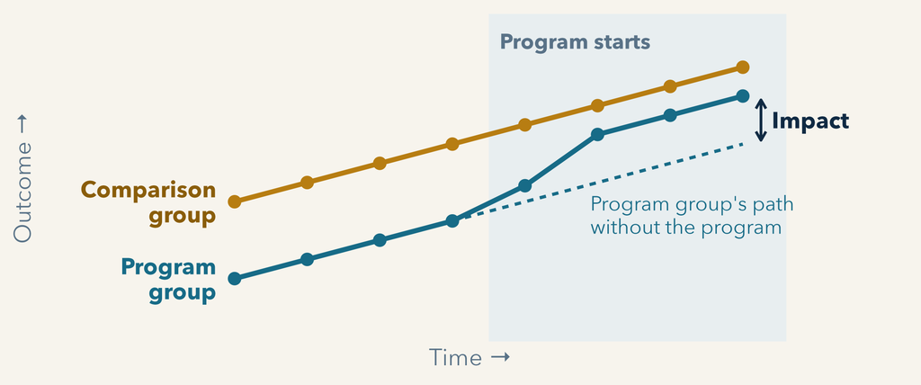

**It assumes** the two groups were on the same track and would have stayed on it. **For IHLA:** compare students who switch into IHLA with students who switch between two other public schools.

Simulated data. Henry calls difference-in-differences the stronger interrupted time-series design (Handbook ch. 6, p. 149)

## Subtract the comparison group’s change from the program group’s change, and what’s left is the program

The napkin math · IHLA, share of students showing ELA growth

Before the moveAfter the moveChange

**Switched into IHLA**55%35%**−20**

**Switched between two other public schools *hypothetical***60%55%**−5**

**Difference in differences**−20 − (−5) =**−15 points**

The −5 is what **switching schools** costs any student. Only the extra −15 is charged to IHLA, and only if both groups would have changed by the same amount without it.

IHLA row: OPE Exhibit 19, p. 43 (55% measured off the chart, 35% printed). Comparison row: invented. OPE did not report students who switched between other schools

## Difference-in-differences works only if the two groups were moving in parallel before the program

The parallel trends assumption

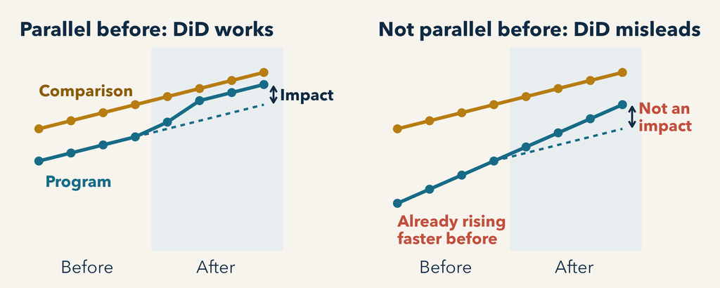

**How to check:** plot several years before the program. If the lines weren’t parallel then, the comparison group’s trend is a poor guess at what would have happened. Henry: be wary when a program starts right after an unusually bad year (p. 149).

Simulated data. Henry, Handbook ch. 6, pp. 148–149: get “several observations” before and after

## Matching builds a look-alike group, but only on the traits you can measure

You can match on

- What’s in the records: income, age, prior test scores
- OPE picked comparison schools with the same charter rules or a similar education services provider (OPE p. 47)

You can’t match on

- Motivation, or why a family chose the program
- The 1969 Westinghouse study of Head Start matched its children with kindergarten classmates who hadn’t attended. Later reanalyses concluded “substantial bias was likely” (p. 151)

Henry: “unobserved differences in the treated and untreated groups may remain, and these differences may bias the impact estimates” (p. 151)

Henry, Handbook ch. 6, pp. 151–152

## Matching on one score pairs each participant with a non-participant who was just as likely to join

Propensity score matching · Rosenbaum and Rubin (1983)

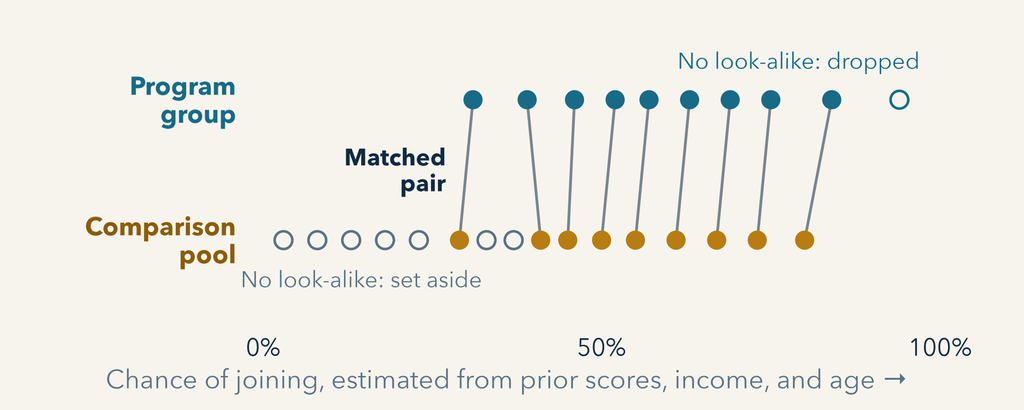

**Then compare outcomes** across the pairs. One score balances many measured traits at once, but Henry warns that the bias left by traits outside the score is **“uncertain”** (p. 152).

Invented example. Henry, Handbook ch. 6, pp. 151–153. Henry, Gordon & Rickman (2006) used it to compare Head Start with a state pre-K program (p. 152)

## Tulsa’s birthday cutoff compared children just old enough for pre-K with children just too young

Regression discontinuity · Tulsa, Oklahoma, universal pre-K

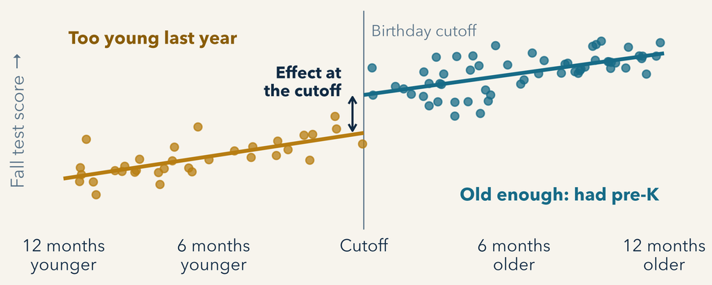

Children just old enough to have attended scored higher on letters and words, spelling, and problem solving. The estimate holds only for children **near the cutoff**.

Simulated data illustrating the Tulsa design (Gormley et al. 2005). Henry, Handbook ch. 6, pp. 153–154: RD has “the strongest claim” of the comparison group designs

## The designs that rule out the most selection bias also need the most data and skill

1**Simple comparison**Henry’s “naïve” design · slide 7

2**Adjust for a before score**“Value-added”

3**Adjust for other measured traits**“Covariates”

4**Adjust for both**Before score plus other traits

5**Difference-in-differences**Trends with a comparison group. Henry: “interrupted time series” · slides 9–11

6**Fixed effects**Same people, with and without · slide 8

7**Matching**Look-alikes on measured traits, or on one score · slides 12–13

8**Regression discontinuity**A cutoff · slide 14

Evaluators “must sometimes choose between **better and worse designs** rather than the best design or no evaluation.”

Henry, Handbook ch. 6, pp. 139, 142–154. Henry orders the eight roughly by accuracy, which is also the order of data and technical demands (p. 142)

## Random assignment

Part 2 · Torgerson, Torgerson, and Taylor, ch. 7 · GAO-10-30

Random assignment

Let chance decide who gets the program, and the two groups start out alike

## When chance picks who gets the program, the groups come out roughly alike, even on traits you never measured

struggled in their last school didn’t · 40 applicants, 20 slots

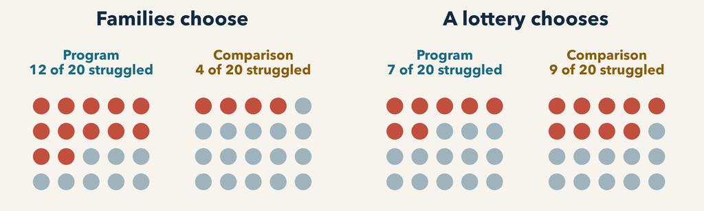

“Random allocation is virtually the only method in which two or more groups that are similar in all known and unknown characteristics can be formed.”

Invented example. Torgerson, Torgerson, and Taylor, Handbook ch. 7, pp. 158, 160. Henry, ch. 6, p. 141: a lottery for oversubscribed pre-K is free of selection bias, while first come, first served favors motivated parents

## Programs with more applicants than slots can randomize fairly

1**Lottery****Draw names for the slots you have**“Assignment by lottery has often been considered the most equitable way to assign individuals to participate in programs with limits on enrollment”*GAO-10-30, p. 23*

2**Waiting list****Everyone gets it, in a random order**A school with too few laptops for all its pupils randomly chose who got the literacy software first. Everyone got it eventually*Ch. 7, p. 166*

3**Phased rollout****Randomize which sites start first**Probation offices in the north of England started a new supervision method one at a time, three months apart, in a random order*Ch. 7, pp. 166–167*

When no one knows whether a program works, a lottery is a fair way to ration it. Ch. 7 goes further: “It is unethical to **widely implement a policy** that increases costs and might not result in benefit.”

Torgerson, Torgerson, and Taylor, Handbook ch. 7, pp. 165–167, 173. GAO-10-30, p. 23

## A randomized trial can still go wrong after the coin flip

**Contamination****The control group gets the program anyway**Teachers told to praise only some children praised the rest too. *Fix:* randomize whole classes or streets (p. 162)

**Attrition****People drop out, and not at random**20% dropout in one group and 10% in the other is “a real worry.” *Fix:* keep following everyone (p. 164)

**Crossover****People switch groups**Analyzing people by what they actually got is “tempting but scientifically incorrect.” *Fix:* analyze everyone in the group they were assigned to (p. 163)

**Rigged assignment****Someone overrides the coin**Some researchers put younger, fitter patients in the treatment group to “prove” it worked. *Fix:* let an outside party randomize (pp. 161–162)

Torgerson, Torgerson, and Taylor, Handbook ch. 7, pp. 161–164

## Random assignment fits some programs and doesn’t fit others

GAO-10-30 · what the literature says about when randomized trials work

Well suited when

- Many things besides the program affect the outcome (job training, where local job markets matter)
- The evaluator controls who gets the program
- The program can’t serve everyone anyway
- The two groups stay separate during the study
- Results show up within one to two years

Not well suited when

- The program covers everyone by law (Social Security, Medicare, veterans’ benefits)
- People choose their own exposure (TV, radio, billboards)
- Testing it means imposing harm (no one can assign a flood)
- Staff won’t deny help to the neediest
- The program varies too much from person to person or site to site to say what “it” is

GAO, *Program Evaluation: A Variety of Rigorous Methods Can Help Identify Effective Interventions* (GAO-10-30, 2009), pp. 22–26

## Should only randomized trials count as proof that a program works?

The Coalition’s “Top Tier” list counted only randomized trials and accepted 6 of 63 programs

**GAO****“Requiring evidence from randomized experiments as sole proof of an intervention’s effectiveness is likely to exclude many potentially effective and worthwhile practices for which random assignment is not practical.”**Six federal evidence reviews accept well-done comparison group studies (pp. 15, 31)

**The Coalition for Evidence-Based Policy****Promising results from nonrandomized studies often don’t hold up.**50–80% of promising early medical results are overturned in later randomized trials. 8 of 9 major trials from the Education Department’s research institute found weak or no positive effects (letter in GAO’s appendix, p. 38)

GAO-10-30 (2009), pp. 4, 15, 19, 31, 37–38

## Before you trust an impact claim, or make one, ask three questions

1**Compared to what?**Who stands in for the program group’s “without the program”: a waiting list, a cutoff, another county, the same people before?

2**Why would they have ended up the same?**Without the program, would the two groups’ outcomes have been roughly the same? Who chose to be in each group?

3**What else changed at the same time?**A new school, a bad year, a policy change, people dropping out or switching groups

Back to IHLA: none of OPE’s three comparisons is the counterfactual. Against the closest one, similar virtual schools, **the gap mostly disappears**.

Henry, Handbook ch. 6, p. 144. OPE, *Idaho Home Learning Academy* (2025), p. 47. Your design matrix (due October 29) needs a design for each evaluation question

## Women as Leaders

Case discussion

Women as Leaders

India reserved a third of village council leader seats for women and rotated them among villages

## Before we leave

**October 29**

Design matrix due by class time, printed

Handbook ch. 23, 27, and 28

Case: Team Read (B)

**November 5**

Cultural competence: Handbook ch. 12

Case: Making Work Pay (Jobs Plus)

**November 12**

Data collection plan due

## An impact estimate is only as believable as its comparison group